# hw2

Edwin Rivas Meraz

1/29/2020

```r
library(ggplot2)
library(dplyr)
# 1
```

?ncol()

NCOL()

```r
# 5
v <- c(8:19)
w <- v[1:4] # first four elements of vector v
w
```

```
## [1]  8  9 10 11
```

```r
# 6
d <- c(8:20)
length(d)
```

```
## [1] 13
```

```r
h <- d[5:9] # middle 5 elements of vector d
h
```

```
## [1] 12 13 14 15 16
```

```r
# 7
length(w)
```

```
## [1] 4
```

```r
# 8
```

- Type: what it is
- Length: amount of elements
- Attributes: additional metadata

```r
# 9
a <- c(3,FALSE)
b <- c("a",1)
c <- c(4L, 2)
```

- “a” would be considered logical if “FALSE” was not coerced into a 0 but it will be considered double
- “b” will be considered as a character due to the letter within it
- “c” will be considered a double

```r
typeof(a)
```

```
## [1] "double"
```

```r
typeof(b)
```

```
## [1] "character"
```

```r
typeof(c)
```

```
## [1] "double"
```

```r
# 10
```

- character
- double
- integer
- logical
- complex (rare)
- raw (rare)

```r
# 11
```

“one< 2” compares a character to an integer and is therefore considered FALSE

```r
# 12
y <- c(FALSE,NA_character_)
typeof(y)
```

```
## [1] "character"
```

Logical vectors are very flexible in that they can be coerced into other data types

```r
# 13
e <- d*2 # multiply each value in d by 2 and assign to e
e
```

```
##  [1] 16 18 20 22 24 26 28 30 32 34 36 38 40
```

```r
e[length(e)]
```

```
## [1] 40
```

```r
# 14
#?seq
a <- seq(from = 0.6, to = 1.9, length.out = 11)
a
```

```
##  [1] 0.60 0.73 0.86 0.99 1.12 1.25 1.38 1.51 1.64 1.77 1.90
```

```r
b <- a >= 1.1
b
```

```
##  [1] FALSE FALSE FALSE FALSE  TRUE  TRUE  TRUE  TRUE  TRUE  TRUE  TRUE
```

```r
# 15
a[a >= 1.1] <- 2.0
a
```

```
##  [1] 0.60 0.73 0.86 0.99 2.00 2.00 2.00 2.00 2.00 2.00 2.00
```

```r
# 16
l <-c(list(1,2),c(3,4))
j=list(list(1,2),c(3,4))
str(l)
```

```
## List of 4
##  $ : num 1
##  $ : num 2
##  $ : num 3
##  $ : num 4
```

```r
str(j)
```

```
## List of 2
##  $ :List of 2
##   ..$ : num 1
##   ..$ : num 2
##  $ : num [1:2] 3 4
```

```r
# 17
unlist(l)
```

```
## [1] 1 2 3 4
```

```r
unlist(j)
```

```
## [1] 1 2 3 4
```

```r
# 18
```

Factors are useful to use character vectors in place of integers which can often be easier to interpret in statistics

```r
# 19
my.fac <- factor(c("yes","yes","no","yes","yes","yes"))
table(my.fac) #freq no and yes
```

```
## my.fac
##  no yes
##   1   5
```

```r
# 20
f1 <- factor(letters)
levels(f1) <-rev(levels(f1))
f2 <- rev(factor(letters))
f3 <- factor(letters, levels=rev(letters))
f1
```

```
##  [1] z y x w v u t s r q p o n m l k j i h g f e d c b a
## Levels: z y x w v u t s r q p o n m l k j i h g f e d c b a
```

```r
f2
```

```
##  [1] z y x w v u t s r q p o n m l k j i h g f e d c b a
## Levels: a b c d e f g h i j k l m n o p q r s t u v w x y z
```

```r
f3
```

```
##  [1] a b c d e f g h i j k l m n o p q r s t u v w x y z
## Levels: z y x w v u t s r q p o n m l k j i h g f e d c b a
```

- f1 revereses both the levels and the values
- f2 did not reverse the levels but did reverse the values
- f3 revereses the levels but not the values

```r
# 21
x <- c(1, 2, 4)
x
```

```
## [1] 1 2 4
```

```r
x[1]
```

```
## [1] 1
```

```r
mymatrix <- matrix(c(1, 3, 5, 8), 2, 2)
mymatrix
```

```
##      [,1] [,2]
## [1,]    1    5
## [2,]    3    8
```

```r
is.matrix(mymatrix)
```

```
## [1] TRUE
```

```r
is.array(mymatrix)
```

```
## [1] TRUE
```

It will return TRUE

```r
# 22
d <- data.frame(kids = c("Jack", "Jill"), ages = c(12, 10))
d
```

| kids | ages |
| --- | --- |
| Jack | 12 |
| Jill | 10 |

Trying to make a data frame that ask for different number of rows by putting two variables under ‘kids’ but 3 variables under ‘ages’

```r
# Bonus
library(tidyverse)
f2 <- tibble(kids=c("Jack","Jill"),ages=c(12,10))
f2
```

| kids | ages |
| --- | --- |
| Jack | 12 |
| Jill | 10 |

A tibble is said to be lazy in transforming the input and will generally ‘complain’ more than data frames, however, this causes potential issues to be addressed earlier and can lead to a well-expressed and robust code

```r
# 23
as.matrix(d)
```

```
##      kids   ages
## [1,] "Jack" "12"
## [2,] "Jill" "10"
```

as.matrix(d) created a matrix where the columns were named ‘kids’ and ‘ages’

```r
# 24
d1 <- data.frame(names = c("Jack", "Jill", "John"), states = c("CA", "IL", "IL"))
d2 <- data.frame(ages = c(10, 7, 12), names = c("Jill", "Jillian", "Jack"))
d1
```

| names | states |
| --- | --- |
| Jack | CA |
| Jill | IL |
| John | IL |

```r
d2
```

| ages | names |
| --- | --- |
| 10 | Jill |
| 7 | Jillian |
| 12 | Jack |

```r
merge(d1, d2)
```

| names | states | ages |
| --- | --- | --- |
| Jack | CA | 12 |
| Jill | IL | 10 |

```r
names(d2) <- c("ages", "kids")
d12 <- merge(d1,d2)
d12
```

| names | states | ages | kids |
| --- | --- | --- | --- |
| Jack | CA | 10 | Jill |
| Jill | IL | 10 | Jill |
| John | IL | 10 | Jill |
| Jack | CA | 7 | Jillian |
| Jill | IL | 7 | Jillian |
| John | IL | 7 | Jillian |
| Jack | CA | 12 | Jack |
| Jill | IL | 12 | Jack |
| John | IL | 12 | Jack |

```r
d2 <- rbind(d2,list("15","Jill"))
d2
```

|  | ages | kids |
| --- | --- | --- |
| 1 | 10 | Jill |
| 2 | 7 | Jillian |
| 3 | 12 | Jack |
| 4 | 15 | Jill |

```r
# 25
empty <- data.frame() # create dataframe with 0 row and 0 column
class(empty) # make sure it is a dataframe
```

```
## [1] "data.frame"
```

```r
empty
```

```r
ncol(empty) # check column
```

```
## [1] 0
```

```r
nrow(empty) # check row
```

```
## [1] 0
```

Yes, you can create a data frame with 0 rows and 0 columns

```r
# 26
x <- iris
x_filter <- filter(x, x$Sepal.Width<=3) # filter out all values of x in the column sepal width to those less than or equal to 3
x_filter$Sepal.Width # print results
```

```
##  [1] 3.0 2.9 3.0 3.0 3.0 3.0 2.3 3.0 2.3 2.8 2.8 2.4 2.9 2.7 2.0 3.0 2.2 2.9 2.9
## [20] 3.0 2.7 2.2 2.5 2.8 2.5 2.8 2.9 3.0 2.8 3.0 2.9 2.6 2.4 2.4 2.7 2.7 3.0 2.3
## [39] 3.0 2.5 2.6 3.0 2.6 2.3 2.7 3.0 2.9 2.9 2.5 2.8 2.7 3.0 2.9 3.0 3.0 2.5 2.9
## [58] 2.5 2.7 3.0 2.5 2.8 3.0 2.6 2.2 2.8 2.8 2.7 2.8 3.0 2.8 3.0 2.8 2.8 2.8 2.6
## [77] 3.0 3.0 2.7 3.0 2.5 3.0 3.0
```

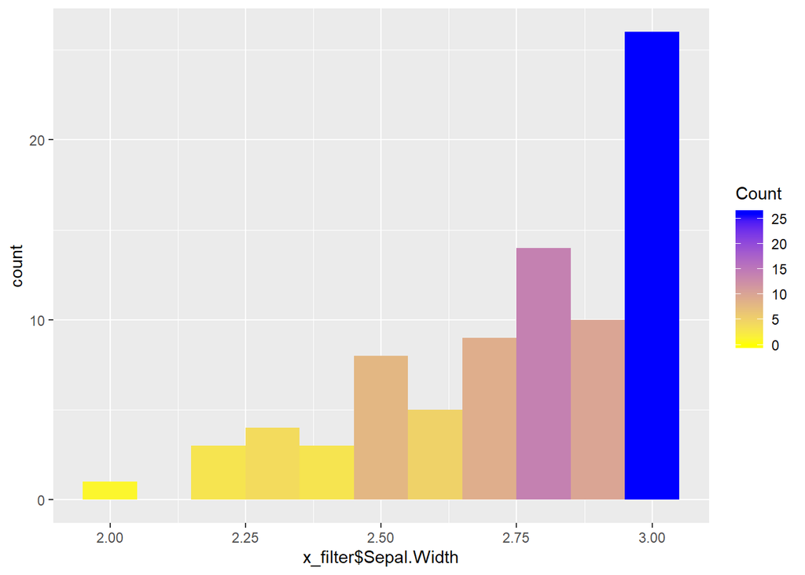

```r
xhist <- ggplot(x_filter, aes(x_filter$Sepal.Width)) +
geom_histogram(aes(fill=..count..), binwidth = 0.1) +
  scale_fill_gradient("Count", low = "yellow", high = "blue") # create histogram
xhist
```

```r
# 27
d <- data.frame(gender = c("M", "M", "F", "M", "F", "F"),
        age=c(47, 59, 21, 32, 33, 24),
        income=c(55000, 88000, 32450, 76500, 123000, 45650))# create data frame d
apply(d, 2, max) #use apply on dataframe d
```

```
##   gender      age   income
##      "M"     "59" "123000"
```

The function returned the maximum value from each column

```r
# 28
```

A function can have a name, an argument, and a body of code. However, an argument is not needed.

```r
# 29
```

The local environment within a function can use ‘return’ to move an object or the value of an object to the global environment

```r
# 30
```

debug()

```r
# 31
```

Ensuring that the function is closed such that the > appears in the console and retyping the function can help debug because common mistakes include unclosed parantheses or braces

```r
# 32
```

- stop()
- stopifnot()

```r
# 33
```

Long functions can likely be split into smaller chunks and can be used to call each other. Keeping functions short is beneficial because it makes code easier to update, easier to identify bugs, and easily testable

```r
# 34
```

Local variables can exist within a function’s environment and cannot be called outside of the function. A function can deliver a global variable using ’return’and a global variable can be included within a function by incliding it within the arguments.

```r
# 35
wave_to_freq <- function(wave) {
  #note wavelength needs to be in meters
  freq <- (299792458/wave) #speed of light in m/s
  freq
}
wave_to_freq(0.02)
```

```
## [1] 14989622900
```

```r
# 36
x <- wave_to_freq(0.02) # assign to object x
x #call object x
```

```
## [1] 14989622900
```

The function still works

```r
# 37

nm_to_m <- function(nm) {
  m <- nm/1E9 #1E9 nanometers equal to 1 meter
  return(m) #return local variable to global environment
}
nm_to_m(900)
```

```
## [1] 9e-07
```

```r
# 38
um_to_ghz <- function(um) {
  ghz <- 299792458/(um/1E6) #speed of light in meters divided by micrometers converted to meters
  return(ghz) #return frequency
}

# 39
um_to_ghz(30000)
```

```
## [1] 9993081933
```

Band = X

```r
# 40
x <- rnorm(40) #generate 40 values normally distributed
head(x) # preview data
```

```
## [1] -0.9989574 -0.3475588 -0.8119691  0.7030088  1.2929632 -0.8131326
```

```r
for (n in x) {
  s <- x[1:10] #extract first 10 elements
  x2 <- s^2 #square the elements called
  return(x2) #return the squared values
}
x2
```

```
##  [1] 0.99791594 0.12079714 0.65929388 0.49422138 1.67175375 0.66118463
##  [7] 4.25972408 0.02009214 0.16116022 0.01359298
```

```r
# 41
e <- 4:29
head(e)
```

```
## [1] 4 5 6 7 8 9
```

```r
for(n in e) {
    if(n %% 2 == 0) # divide by 2 and keep value if remainder is 0
    print(n) # return object
}
```

```
## [1] 4
## [1] 6
## [1] 8
## [1] 10
## [1] 12
## [1] 14
## [1] 16
## [1] 18
## [1] 20
## [1] 22
## [1] 24
## [1] 26
## [1] 28
```

```r
# 42
m <- 100:190
str(m)
```

```
##  int [1:91] 100 101 102 103 104 105 106 107 108 109 ...
```

```r
countby10 <- for (n in m) {if (n %% 10 == 0) {print(n)

}

}
```

```
## [1] 100
## [1] 110
## [1] 120
## [1] 130
## [1] 140
## [1] 150
## [1] 160
## [1] 170
## [1] 180
## [1] 190
```

```r
# 43
z <- matrix(sample(100), 10, 10) # create matrix
zlist <- list(z=z) #create list
lapply(X = zlist, FUN = function(x) {
  z[3, ] <- 'ciao' # replace values in third row with ciao
  z[, 5] <- 'ciao' #replace values in column 5 with ciao
  return(z) # return object
})
```

```
## $z
##       [,1]   [,2]   [,3]   [,4]   [,5]   [,6]   [,7]   [,8]   [,9]   [,10]
##  [1,] "80"   "54"   "83"   "39"   "ciao" "90"   "27"   "92"   "2"    "66"
##  [2,] "65"   "23"   "74"   "26"   "ciao" "14"   "47"   "10"   "37"   "95"
##  [3,] "ciao" "ciao" "ciao" "ciao" "ciao" "ciao" "ciao" "ciao" "ciao" "ciao"
##  [4,] "35"   "51"   "38"   "85"   "ciao" "13"   "59"   "70"   "69"   "61"
##  [5,] "99"   "1"    "34"   "25"   "ciao" "12"   "63"   "50"   "28"   "56"
##  [6,] "15"   "88"   "42"   "40"   "ciao" "33"   "31"   "48"   "5"    "84"
##  [7,] "19"   "81"   "86"   "3"    "ciao" "75"   "94"   "45"   "43"   "91"
##  [8,] "18"   "78"   "17"   "64"   "ciao" "16"   "24"   "58"   "77"   "8"
##  [9,] "53"   "21"   "32"   "89"   "ciao" "46"   "29"   "68"   "79"   "11"
## [10,] "98"   "57"   "71"   "76"   "ciao" "93"   "52"   "4"    "44"   "72"
```

```r
# 44
```

A loop is a series of specificed and organized actions for datapoints or other variables/parts to undergo . In my project I have various treatments for sediments which are incubated in triplicate and can lead to a large dataset of a wide variety of variables that often need a change in the units it is expressed in. A for-loop can help calculate the conversions from one unit to another.

```r
# 45
foo = seq(1, 100, by=2) # create object 1-100 count by 2
foo
```

```
##  [1]  1  3  5  7  9 11 13 15 17 19 21 23 25 27 29 31 33 35 37 39 41 43 45 47 49
## [26] 51 53 55 57 59 61 63 65 67 69 71 73 75 77 79 81 83 85 87 89 91 93 95 97 99
```

```r
foo.squared = NULL #create empty vector to populate
foo.squared
```

```r
for (i in 1:50 ) {
foo.squared[i] = foo[i]^2 #square values in foo and grow in foo.squared
}
foo.squared
```

```
##  [1]    1    9   25   49   81  121  169  225  289  361  441  529  625  729  841
## [16]  961 1089 1225 1369 1521 1681 1849 2025 2209 2401 2601 2809 3025 3249 3481
## [31] 3721 3969 4225 4489 4761 5041 5329 5625 5929 6241 6561 6889 7225 7569 7921
## [46] 8281 8649 9025 9409 9801
```

We can create an empty vector (foo.squared) and use a loop to populate or ‘grow’ variables passed through the ‘for’ loop that squares the values in foo

```r
# 46
```

People look down on loops in R because they are oten slower than applying a command to a vector. The apply functions are preffered as opposed to a for-loop however apply functions are built with for-loops within them and are therefore not faster than for-loops. Loops are useful if you want to apply the same set of functions to a large set of datapoints.

```r
# 47
mtcars
```

|  | mpg | cyl | disp | hp | drat | wt | qsec | vs | am | gear | carb |
| --- | --- | --- | --- | --- | --- | --- | --- | --- | --- | --- | --- |
| Mazda RX4 | 21.0 | 6 | 160.0 | 110 | 3.90 | 2.620 | 16.46 | 0 | 1 | 4 | 4 |
| Mazda RX4 Wag | 21.0 | 6 | 160.0 | 110 | 3.90 | 2.875 | 17.02 | 0 | 1 | 4 | 4 |
| Datsun 710 | 22.8 | 4 | 108.0 | 93 | 3.85 | 2.320 | 18.61 | 1 | 1 | 4 | 1 |
| Hornet 4 Drive | 21.4 | 6 | 258.0 | 110 | 3.08 | 3.215 | 19.44 | 1 | 0 | 3 | 1 |
| Hornet Sportabout | 18.7 | 8 | 360.0 | 175 | 3.15 | 3.440 | 17.02 | 0 | 0 | 3 | 2 |
| Valiant | 18.1 | 6 | 225.0 | 105 | 2.76 | 3.460 | 20.22 | 1 | 0 | 3 | 1 |
| Duster 360 | 14.3 | 8 | 360.0 | 245 | 3.21 | 3.570 | 15.84 | 0 | 0 | 3 | 4 |
| Merc 240D | 24.4 | 4 | 146.7 | 62 | 3.69 | 3.190 | 20.00 | 1 | 0 | 4 | 2 |
| Merc 230 | 22.8 | 4 | 140.8 | 95 | 3.92 | 3.150 | 22.90 | 1 | 0 | 4 | 2 |
| Merc 280 | 19.2 | 6 | 167.6 | 123 | 3.92 | 3.440 | 18.30 | 1 | 0 | 4 | 4 |

[output cut: 22 more lines]

```r
cars <- mtcars
unlist(lapply(cars, class))
```

```
##       mpg       cyl      disp        hp      drat        wt      qsec        vs
## "numeric" "numeric" "numeric" "numeric" "numeric" "numeric" "numeric" "numeric"
##        am      gear      carb
## "numeric" "numeric" "numeric"
```

```r
cars[] <- lapply(cars, function(x) sd(x)/mean(x))
cars[1, ]
```

|  | mpg | cyl | disp | hp | drat | wt | qsec | vs | am | gear | carb |
| --- | --- | --- | --- | --- | --- | --- | --- | --- | --- | --- | --- |
| Mazda RX4 | 0.2999881 | 0.2886338 | 0.5371779 | 0.4674077 | 0.1486638 | 0.3041285 | 0.1001159 | 1.152037 | 1.228285 | 0.2000825 | 0.5742933 |

```r
# 48
scale01 <- function (x) {
  rng <-range(x, na.rm=TRUE)
  (x-rng[1] / rng[2] - rng[1])
}
x <- data.frame(seq(1:26), letters, rnorm(26))
x
```

| seq.1.26. | letters | rnorm.26. |
| --- | --- | --- |
| 1 | a | -1.75202364 |
| 2 | b | -1.42250512 |
| 3 | c | -1.67546002 |
| 4 | d | -1.73247288 |
| 5 | e | -0.55990765 |
| 6 | f | -0.50764448 |
| 7 | g | 0.37563797 |
| 8 | h | 0.14334625 |
| 9 | i | -0.30015668 |
| 10 | j | 0.07707623 |

[output cut: 16 more lines]

```r
xn <-lapply(select_if(x, is.numeric), scale01) #every numeric column
xn
```

```
## $seq.1.26.
##  [1] -0.03846154  0.96153846  1.96153846  2.96153846  3.96153846  4.96153846
##  [7]  5.96153846  6.96153846  7.96153846  8.96153846  9.96153846 10.96153846
## [13] 11.96153846 12.96153846 13.96153846 14.96153846 15.96153846 16.96153846
## [19] 17.96153846 18.96153846 19.96153846 20.96153846 21.96153846 22.96153846
## [25] 23.96153846 24.96153846
##
## $rnorm.26.
##  [1] 0.9568676 1.2863861 1.0334312 0.9764184 2.1489836 2.2012468 3.0845292
##  [8] 2.8522375 2.4087346 2.7859675 3.6862383 2.8488378 4.1189506 2.0102815
## [15] 2.9374986 1.4869472 1.3616456 2.1482239 3.8406735 2.8731896 4.5398903
## [22] 1.8796322 3.0538702 2.6160971 2.8992270 1.4802532
```

```r
# 49
formulas <- list(
  mpg ~ disp,
  mpg ~ I(1 / disp),
  mpg ~ disp + wt,
  mpg ~ I(1 / disp) + wt
)
r <- list()
r
```

```
## list()
```

```r
for (i in 1:length(formulas)){
  r[[i]] <- lm(formulas[[i]],
               data = mtcars)
}
r
```

```
## [[1]]
##
## Call:
## lm(formula = formulas[[i]], data = mtcars)
##
## Coefficients:
## (Intercept)         disp
##    29.59985     -0.04122
##
##
## [[2]]
##
## Call:
## lm(formula = formulas[[i]], data = mtcars)
##
## Coefficients:
## (Intercept)    I(1/disp)
##       10.75      1557.67
##
##
## [[3]]
##
## Call:
## lm(formula = formulas[[i]], data = mtcars)
##
## Coefficients:
## (Intercept)         disp           wt
##    34.96055     -0.01772     -3.35083
##
##
## [[4]]
##
## Call:
## lm(formula = formulas[[i]], data = mtcars)
##
## Coefficients:
## (Intercept)    I(1/disp)           wt
##      19.024     1142.560       -1.798
```

```r
# 50

ti.for <- Sys.time()
r <- list()
for (i in 1:length(formulas)){
  r[[i]] <- lm(formulas[[i]],
               data = mtcars)}
te.for <- Sys.time()
t.for <- te.for-ti.for
t.for # time difference it took to run the for loop
```

```
## Time difference of 0.01795197 secs
```

```r
ti.lapply <- Sys.time()
lapply(formulas, function(x) lm(formula = x, data = mtcars))
```

```
## [[1]]
##
## Call:
## lm(formula = x, data = mtcars)
##
## Coefficients:
## (Intercept)         disp
##    29.59985     -0.04122
##
##
## [[2]]
##
## Call:
## lm(formula = x, data = mtcars)
##
## Coefficients:
## (Intercept)    I(1/disp)
##       10.75      1557.67
##
##
## [[3]]
##
## Call:
## lm(formula = x, data = mtcars)
##
## Coefficients:
## (Intercept)         disp           wt
##    34.96055     -0.01772     -3.35083
##
##
## [[4]]
##
## Call:
## lm(formula = x, data = mtcars)
##
## Coefficients:
## (Intercept)    I(1/disp)           wt
##      19.024     1142.560       -1.798
```

```r
te.lapply <- Sys.time()
t.lapply <- te.lapply-ti.lapply
t.lapply #time difference it took for lapply
```

```
## Time difference of 0.01595902 secs
```

```r
time.diff <- t.for-t.lapply
time.diff #time difference between for loop and lapply
```

```
## Time difference of 0.001992941 secs
```